# Data Analysis Assignment W07

Callum Arnold

# Introduction

```r
library(ISLR)
library(tidyverse)
library(caret)
library(MASS)
library(class)
library(kableExtra)
library(hrbrthemes)
library(janitor)

RNGkind(sample.kind = "Rounding")
set.seed(1)

theme_set(theme_ipsum())
```

# Data

```r
data("Weekly")
glimpse(Weekly)
```

```
Rows: 1,089
Columns: 9
$ Year      <dbl> 1990, 1990, 1990, 1990, 1990, 1990, 1990, 1990, 1990, 1990,…
$ Lag1      <dbl> 0.816, -0.270, -2.576, 3.514, 0.712, 1.178, -1.372, 0.807, …
$ Lag2      <dbl> 1.572, 0.816, -0.270, -2.576, 3.514, 0.712, 1.178, -1.372, …
$ Lag3      <dbl> -3.936, 1.572, 0.816, -0.270, -2.576, 3.514, 0.712, 1.178, …
$ Lag4      <dbl> -0.229, -3.936, 1.572, 0.816, -0.270, -2.576, 3.514, 0.712,…
$ Lag5      <dbl> -3.484, -0.229, -3.936, 1.572, 0.816, -0.270, -2.576, 3.514…
$ Volume    <dbl> 0.1549760, 0.1485740, 0.1598375, 0.1616300, 0.1537280, 0.15…
$ Today     <dbl> -0.270, -2.576, 3.514, 0.712, 1.178, -1.372, 0.807, 0.041, …
$ Direction <fct> Down, Down, Up, Up, Up, Down, Up, Up, Up, Down, Down, Up, U…
```

```r
tibble(
  Variable = names(Weekly),
  Description = c(
    "The year that the observation was recorded",
    "Percentage return for previous week",
    "Percentage return for 2 weeks previous",
    "Percentage return for 3 weeks previous",
    "Percentage return for 4 weeks previous",
    "Percentage return for 5 weeks previous",
    "Volume of shares traded (average number of daily shares traded in billions)",
    "Percentage return for this week",
    "A factor with levels Down and Up indicating whether the market had a positive or negative return on a given week"
  )
) %>%
    kable() %>%
    kable_styling(
        bootstrap_options = c("striped", "hover", "condensed", "responsive"),
        full_width = F)
```

| Variable | Description |
| --- | --- |
| Year | The year that the observation was recorded |
| Lag1 | Percentage return for previous week |
| Lag2 | Percentage return for 2 weeks previous |
| Lag3 | Percentage return for 3 weeks previous |
| Lag4 | Percentage return for 4 weeks previous |
| Lag5 | Percentage return for 5 weeks previous |
| Volume | Volume of shares traded (average number of daily shares traded in billions) |
| Today | Percentage return for this week |
| Direction | A factor with levels Down and Up indicating whether the market had a positive or negative return on a given week |

## Data Summary

```r
summary(Weekly)
```

```
      Year           Lag1               Lag2               Lag3
 Min.   :1990   Min.   :-18.1950   Min.   :-18.1950   Min.   :-18.1950
 1st Qu.:1995   1st Qu.: -1.1540   1st Qu.: -1.1540   1st Qu.: -1.1580
 Median :2000   Median :  0.2410   Median :  0.2410   Median :  0.2410
 Mean   :2000   Mean   :  0.1506   Mean   :  0.1511   Mean   :  0.1472
 3rd Qu.:2005   3rd Qu.:  1.4050   3rd Qu.:  1.4090   3rd Qu.:  1.4090
 Max.   :2010   Max.   : 12.0260   Max.   : 12.0260   Max.   : 12.0260
      Lag4               Lag5              Volume            Today
 Min.   :-18.1950   Min.   :-18.1950   Min.   :0.08747   Min.   :-18.1950
 1st Qu.: -1.1580   1st Qu.: -1.1660   1st Qu.:0.33202   1st Qu.: -1.1540
 Median :  0.2380   Median :  0.2340   Median :1.00268   Median :  0.2410
 Mean   :  0.1458   Mean   :  0.1399   Mean   :1.57462   Mean   :  0.1499
 3rd Qu.:  1.4090   3rd Qu.:  1.4050   3rd Qu.:2.05373   3rd Qu.:  1.4050
 Max.   : 12.0260   Max.   : 12.0260   Max.   :9.32821   Max.   : 12.0260
 Direction
 Down:484
 Up  :605
```

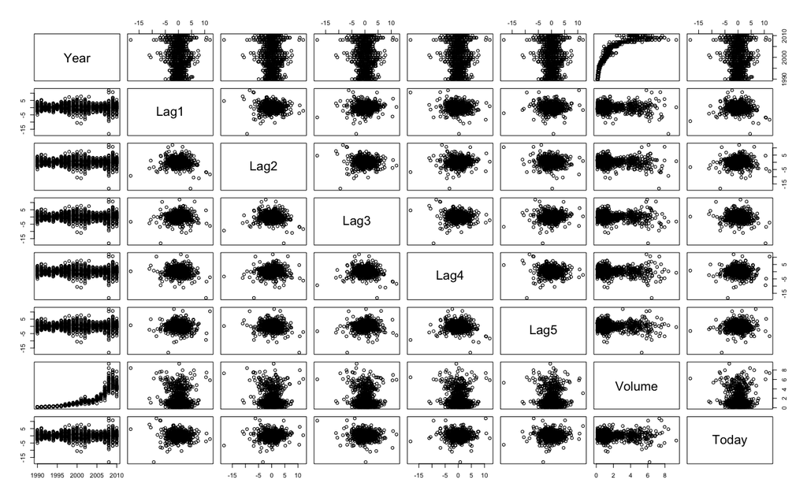

```r
pairs(Weekly[, -9])
```

Examining the correlations, only volume and the year have significant correlations, indicating no particular patterns that need to be addressed in the data. For a further exploration of this relationship, a line plot was created, demonstrating a steady increase since 1990 to a large peak in trading volume around 2008-2009, before a slight decline.

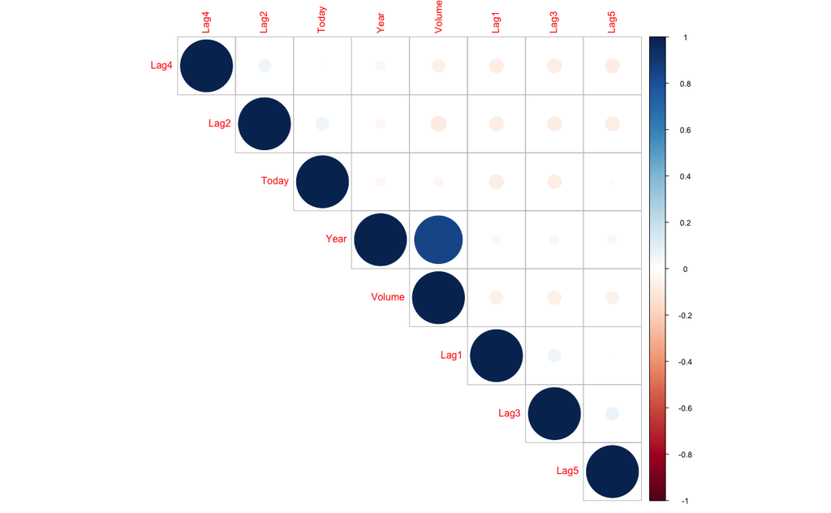

```r
library(corrplot)
corr_matrix <- as.matrix(cor(Weekly[, -9]))
corrplot(corr_matrix, order="hclust",type="upper")
```

```r
corr_matrix%>%
    kable() %>%
    kable_styling(
        bootstrap_options = c("striped", "hover", "condensed", "responsive"),
        full_width = F)
```

|  | Year | Lag1 | Lag2 | Lag3 | Lag4 | Lag5 | Volume | Today |
| --- | --- | --- | --- | --- | --- | --- | --- | --- |
| Year | 1.0000000 | -0.0322893 | -0.0333900 | -0.0300065 | -0.0311279 | -0.0305191 | 0.8419416 | -0.0324599 |
| Lag1 | -0.0322893 | 1.0000000 | -0.0748531 | 0.0586357 | -0.0712739 | -0.0081831 | -0.0649513 | -0.0750318 |
| Lag2 | -0.0333900 | -0.0748531 | 1.0000000 | -0.0757209 | 0.0583815 | -0.0724995 | -0.0855131 | 0.0591667 |
| Lag3 | -0.0300065 | 0.0586357 | -0.0757209 | 1.0000000 | -0.0753959 | 0.0606572 | -0.0692877 | -0.0712436 |
| Lag4 | -0.0311279 | -0.0712739 | 0.0583815 | -0.0753959 | 1.0000000 | -0.0756750 | -0.0610746 | -0.0078259 |
| Lag5 | -0.0305191 | -0.0081831 | -0.0724995 | 0.0606572 | -0.0756750 | 1.0000000 | -0.0585174 | 0.0110127 |
| Volume | 0.8419416 | -0.0649513 | -0.0855131 | -0.0692877 | -0.0610746 | -0.0585174 | 1.0000000 | -0.0330778 |
| Today | -0.0324599 | -0.0750318 | 0.0591667 | -0.0712436 | -0.0078259 | 0.0110127 | -0.0330778 | 1.0000000 |

```r
Weekly$Week <- 1:nrow(Weekly)

year_breaks <- Weekly %>%
  group_by(Year) %>%
  summarize(Week = min(Week))
```

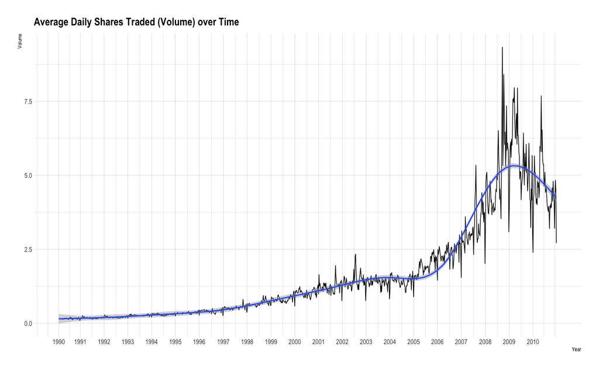

```r
ggplot(Weekly, aes(x = Week, y = Volume)) +
  geom_line() +
  geom_smooth() +
  scale_x_continuous(
    breaks = year_breaks$Week,
    labels = year_breaks$Year
  ) +
    scale_color_ipsum() +
  labs(
    title = "Average Daily Shares Traded (Volume) over Time",
    x = "Year"
  )
```

As would be expected from the line plot of volume over time, the majority of the years see a positive return for > 50% of the weeks in a year (`Direction` = “Up”). Over the course of the 21 years, 55.6% of all weeks see a positive return. However, there are varying amounts of variance seen from year-to-year in the weekly percentage return (`Today`), with a roughly sinusoidal pattern and peaks in variance returning every 10 years.

```r
Weekly %>%
    tabyl(Direction, Year) %>%
    adorn_percentages(denominator = "col") %>%
    adorn_pct_formatting(digits = 1, affix_sign = TRUE) %>%
    kable() %>%
    kable_styling(
        bootstrap_options = c("striped", "hover", "condensed", "responsive"),
        full_width = F)
```

| Direction | 1990 | 1991 | 1992 | 1993 | 1994 | 1995 | 1996 | 1997 | 1998 | 1999 | 2000 | 2001 | 2002 | 2003 | 2004 | 2005 | 2006 | 2007 | 2008 | 2009 | 2010 |
| --- | --- | --- | --- | --- | --- | --- | --- | --- | --- | --- | --- | --- | --- | --- | --- | --- | --- | --- | --- | --- | --- |
| Down | 48.9% | 40.4% | 44.2% | 40.4% | 48.1% | 30.8% | 39.6% | 46.2% | 36.5% | 42.3% | 55.8% | 51.9% | 57.7% | 34.6% | 46.2% | 42.3% | 44.2% | 45.3% | 55.8% | 44.2% | 38.5% |
| Up | 51.1% | 59.6% | 55.8% | 59.6% | 51.9% | 69.2% | 60.4% | 53.8% | 63.5% | 57.7% | 44.2% | 48.1% | 42.3% | 65.4% | 53.8% | 57.7% | 55.8% | 54.7% | 44.2% | 55.8% | 61.5% |

```r
prop.table(table(Direction = Weekly$Direction)) %>%
    kable() %>%
    kable_styling(
        bootstrap_options = c("striped", "hover", "condensed", "responsive"),
        full_width = F)
```

| Direction | Freq |
| --- | --- |
| Down | 0.4444444 |
| Up | 0.5555556 |

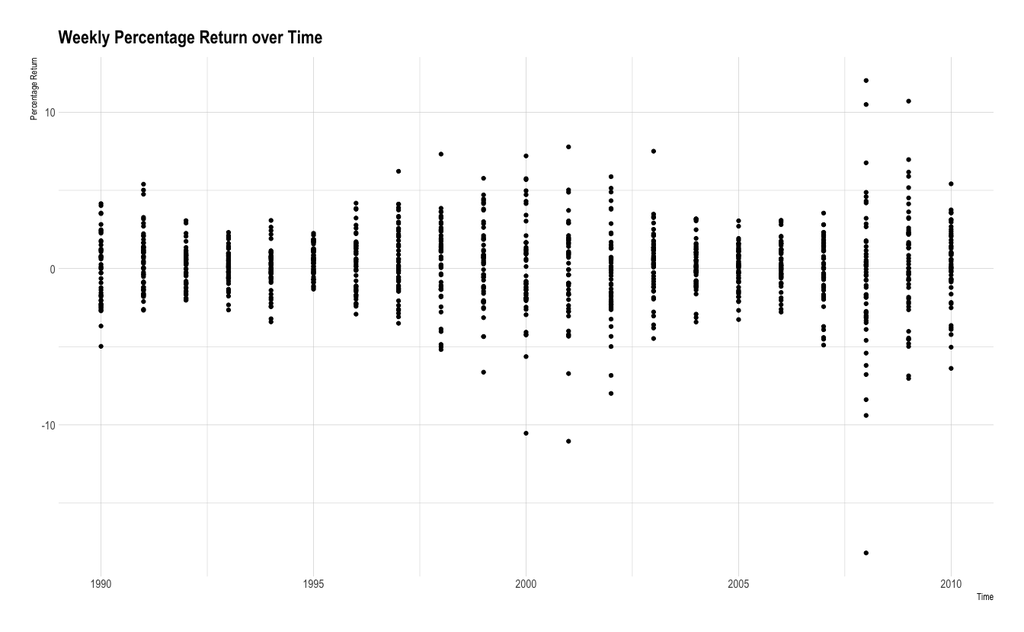

```r
ggplot(Weekly, aes(x = Year, y = Today)) +
  geom_point() +
  labs(
    title = "Weekly Percentage Return over Time",
    x = "Time",
    y = "Percentage Return"
  )
```

# Logistic Regression

Performing a logistic regression on the full dataset, including all variables, `Lag2` appears to be the only statistically significant predictor of `Direction`, with a p = 0.03.

```r
lr_full <- glm(Direction ~ Lag1 + Lag2 + Lag3 + Lag4 + Lag5 + Volume,
  data = Weekly,
  family = "binomial"
)

summary(lr_full)
```

```
Call:
glm(formula = Direction ~ Lag1 + Lag2 + Lag3 + Lag4 + Lag5 +
    Volume, family = "binomial", data = Weekly)

Deviance Residuals:
    Min       1Q   Median       3Q      Max
-1.6949  -1.2565   0.9913   1.0849   1.4579

Coefficients:
            Estimate Std. Error z value Pr(>|z|)
(Intercept)  0.26686    0.08593   3.106   0.0019 **
Lag1        -0.04127    0.02641  -1.563   0.1181
Lag2         0.05844    0.02686   2.175   0.0296 *
Lag3        -0.01606    0.02666  -0.602   0.5469
Lag4        -0.02779    0.02646  -1.050   0.2937
Lag5        -0.01447    0.02638  -0.549   0.5833
Volume      -0.02274    0.03690  -0.616   0.5377
---
Signif. codes:  0 ‘***’ 0.001 ‘**’ 0.01 ‘*’ 0.05 ‘.’ 0.1 ‘ ’ 1

(Dispersion parameter for binomial family taken to be 1)

    Null deviance: 1496.2  on 1088  degrees of freedom
Residual deviance: 1486.4  on 1082  degrees of freedom
AIC: 1500.4

Number of Fisher Scoring iterations: 4
```

## Confusion Matrix

Computing the confusion matrix for the logistic regression of the full dataset, it can be seen that it has an accuracy of 56.1%, a sensitivity of 92.1% (correctly predicts `Direction` “Up”), and a specificity of only 11.1%. These numbers highlight that the logistic regression is predicting that the stock market returns will increase virtually all the time, very rarely predicting the “Down” `Direction`, something that would be desirable to overcome in different models.

```r
predicted <- factor(
  ifelse(
    predict(lr_full, type = "response") < 0.5,
    "Down",
    "Up"
  )
)
```

```r
confusionMatrix(predicted, Weekly$Direction, positive = "Up")
```

```
Confusion Matrix and Statistics

          Reference
Prediction Down  Up
      Down   54  48
      Up    430 557

               Accuracy : 0.5611
                 95% CI : (0.531, 0.5908)
    No Information Rate : 0.5556
    P-Value [Acc > NIR] : 0.369

                  Kappa : 0.035

 Mcnemar's Test P-Value : <2e-16

            Sensitivity : 0.9207
            Specificity : 0.1116
         Pos Pred Value : 0.5643
         Neg Pred Value : 0.5294
             Prevalence : 0.5556
         Detection Rate : 0.5115
   Detection Prevalence : 0.9063
      Balanced Accuracy : 0.5161

       'Positive' Class : Up
```

```r
prop.table(table(predicted))
```

```
predicted
      Down         Up
0.09366391 0.90633609
```

# Test and Train Data

```r
train <- filter(Weekly, Year <= 2008)
test <- filter(Weekly, Year > 2008)
```

## Logistic Regression

Splitting the data into testing and training sets (before and after 2008), and using `Lag2` as the only predictor (the only predictor with significance), the logistic regression model demonstrates similar performance, over estimating the positive returns of the market. The specificity and accuracy are both improved in this more parsimonious model, however, it performs worse when altering the test-train split to the year 2007, so is likely not a meaningful improvement and an artifact of the small test size. The p-value associated with the `Acc > NIR` is 0.24. This indicates the probability of the accuracy exceeding that of randomly allocating classes (`No Information Rate`). With a p = 0.24, the logistic regression model is not a significant improvement over random chance.

```r
lr_split<- glm(Direction ~ Lag2,
  data = train,
  family = "binomial"
)

predicted_lr <- factor(
  ifelse(
    predict(lr_split, newdata = test, type = "response") < 0.5,
    "Down",
    "Up"
  )
)
```

```r
confusionMatrix(predicted_lr, test$Direction, positive = "Up")
```

```
Confusion Matrix and Statistics

          Reference
Prediction Down Up
      Down    9  5
      Up     34 56

               Accuracy : 0.625
                 95% CI : (0.5247, 0.718)
    No Information Rate : 0.5865
    P-Value [Acc > NIR] : 0.2439

                  Kappa : 0.1414

 Mcnemar's Test P-Value : 7.34e-06

            Sensitivity : 0.9180
            Specificity : 0.2093
         Pos Pred Value : 0.6222
         Neg Pred Value : 0.6429
             Prevalence : 0.5865
         Detection Rate : 0.5385
   Detection Prevalence : 0.8654
      Balanced Accuracy : 0.5637

       'Positive' Class : Up
```

## LDA

LDA performs identically to the logistic regression on the test data set.

```r
lda_split <- lda(Direction ~ Lag2, data = train)

predicted_lda <- predict(lda_split, newdata = test)
```

```r
confusionMatrix(
  data = predicted_lda$class,
  reference = test$Direction,
  positive = "Up"
)
```

```
Confusion Matrix and Statistics

          Reference
Prediction Down Up
      Down    9  5
      Up     34 56

               Accuracy : 0.625
                 95% CI : (0.5247, 0.718)
    No Information Rate : 0.5865
    P-Value [Acc > NIR] : 0.2439

                  Kappa : 0.1414

 Mcnemar's Test P-Value : 7.34e-06

            Sensitivity : 0.9180
            Specificity : 0.2093
         Pos Pred Value : 0.6222
         Neg Pred Value : 0.6429
             Prevalence : 0.5865
         Detection Rate : 0.5385
   Detection Prevalence : 0.8654
      Balanced Accuracy : 0.5637

       'Positive' Class : Up
```

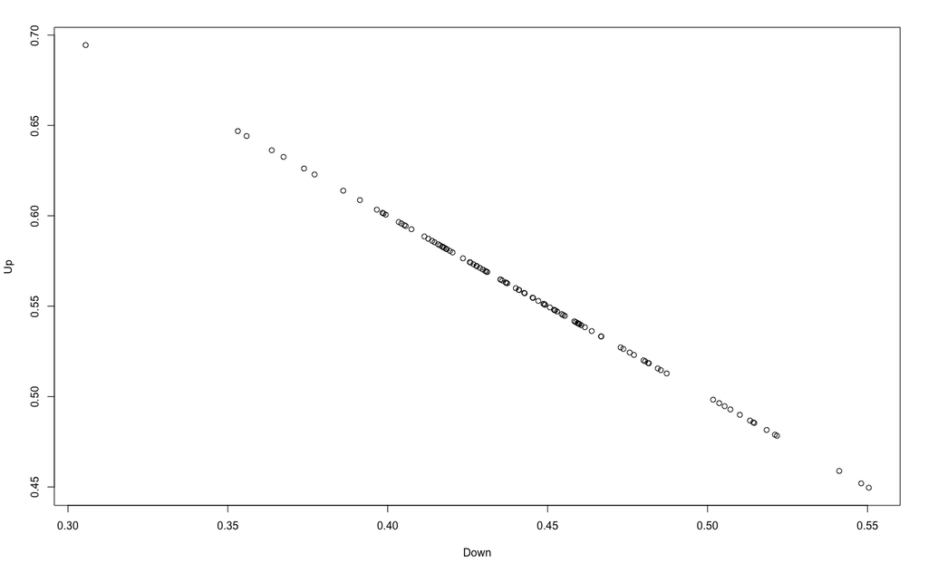

```r
plot(predicted_lda$posterior)
```

```r
# Range of posterio values for Down
range(predicted_lda$posterior[, 1])
```

```
[1] 0.3055404 0.5504246
```

```r
# Range of posterio values for UP
range(predicted_lda$posterior[, 2])
```

```
[1] 0.4495754 0.6944596
```

## QDA

```r
qda_dir <- qda(Direction ~ Lag2, data = train)


predicted_qda <- predict(qda_dir, newdata = test)
```

```r
confusionMatrix(
  data = predicted_qda$class,
  reference = test$Direction,
  positive = "Up"
)
```

```
Confusion Matrix and Statistics

          Reference
Prediction Down Up
      Down    0  0
      Up     43 61

               Accuracy : 0.5865
                 95% CI : (0.4858, 0.6823)
    No Information Rate : 0.5865
    P-Value [Acc > NIR] : 0.5419

                  Kappa : 0

 Mcnemar's Test P-Value : 1.504e-10

            Sensitivity : 1.0000
            Specificity : 0.0000
         Pos Pred Value : 0.5865
         Neg Pred Value :    NaN
             Prevalence : 0.5865
         Detection Rate : 0.5865
   Detection Prevalence : 1.0000
      Balanced Accuracy : 0.5000

       'Positive' Class : Up
```

## KNN

K-Nearest Neighbours also did not perform any better than LR and LDA on the test data when `Lag2` is the only predictor, using accuracy and NIR as the validation metrics. Whilst specificity was greatly improved, particularly when `k = 1`, sensitivity was much lower, resulting in lower accuracy than LDA and LR, which is as expected when > 50% of years were predominantly in the “Up” `Direction` (meaning it was less accurate predicting the predominant `Direction`). `k = 3` had a slightly higher accuracy than `k = 1`.

```r
tibble(
  Statistic = c(
      "Accuracy",
      "95% CI" ,
      "No Information Rate",
      "P-Value [Acc > NIR]",
      "Sensitivity",
      "Specificity"
  ),
  `k = 1` = c(
    "0.5",
    "0.4003 - 0.5997",
    "0.5865",
    "0.9700",
    "0.5082",
    "0.4884"
  ),
  `k = 3` = c(
    "0.5577",
    "0.457 - 0.655",
    "0.5865",
    "0.7579",
    "0.6885",
    "0.3721"
  )
) %>%
    kable() %>%
    kable_styling(
        bootstrap_options = c("striped", "hover", "condensed", "responsive"),
        full_width = F)
```

| Statistic | k = 1 | k = 3 |
| --- | --- | --- |
| Accuracy | 0.5 | 0.5577 |
| 95% CI | 0.4003 - 0.5997 | 0.457 - 0.655 |
| No Information Rate | 0.5865 | 0.5865 |
| P-Value [Acc > NIR] | 0.9700 | 0.7579 |
| Sensitivity | 0.5082 | 0.6885 |
| Specificity | 0.4884 | 0.3721 |

### k = 1

```r
set.seed(1)
```

```r
predicted_knn_1 <- knn(
  train = data.frame(Lag2 = train$Lag2),
  test = data.frame(Lag2 = test$Lag2),
  cl = train$Direction,
  k = 1
)
```

```r
confusionMatrix(
  data = predicted_knn,
  reference = test$Direction,
  positive = "Up"
)
```

```
Confusion Matrix and Statistics

          Reference
Prediction Down Up
      Down   21 30
      Up     22 31

               Accuracy : 0.5
                 95% CI : (0.4003, 0.5997)
    No Information Rate : 0.5865
    P-Value [Acc > NIR] : 0.9700

                  Kappa : -0.0033

 Mcnemar's Test P-Value : 0.3317

            Sensitivity : 0.5082
            Specificity : 0.4884
         Pos Pred Value : 0.5849
         Neg Pred Value : 0.4118
             Prevalence : 0.5865
         Detection Rate : 0.2981
   Detection Prevalence : 0.5096
      Balanced Accuracy : 0.4983

       'Positive' Class : Up
```

### k = 3

```r
predicted_knn_3 <- knn(
  train = data.frame(Lag2 = train$Lag2),
  test = data.frame(Lag2 = test$Lag2),
  cl = train$Direction,
  k = 3
)
```

```r
confusionMatrix(
  data = predicted_knn_3,
  reference = test$Direction,
  positive = "Up"
)
```

```
Confusion Matrix and Statistics

          Reference
Prediction Down Up
      Down   16 19
      Up     27 42

               Accuracy : 0.5577
                 95% CI : (0.457, 0.655)
    No Information Rate : 0.5865
    P-Value [Acc > NIR] : 0.7579

                  Kappa : 0.0623

 Mcnemar's Test P-Value : 0.3020

            Sensitivity : 0.6885
            Specificity : 0.3721
         Pos Pred Value : 0.6087
         Neg Pred Value : 0.4571
             Prevalence : 0.5865
         Detection Rate : 0.4038
   Detection Prevalence : 0.6635
      Balanced Accuracy : 0.5303

       'Positive' Class : Up
```

# Best Performing Classifier

```r
tibble(
  Statistic = c(
      "Accuracy",
      "95% CI" ,
      "No Information Rate",
      "P-Value [Acc > NIR]",
      "Sensitivity",
      "Specificity"
  ),
  `Logistic Regression` = c(
    "0.625",
    "0.5247 - 0.718",
    "0.5865",
    "0.2439",
    "0.9180",
    "0.2093"
  ),
  LDA = c(
    "0.625",
    "0.5247 - 0.718",
    "0.5865",
    "0.2439",
    "0.9180",
    "0.2093"
  ),
  QDA = c(
    "0.5865",
    "0.4858 - 0.6823",
    "0.5865",
    "0.5419",
    "1.0000",
    "0.0000"
  ),
  `k = 1` = c(
    "0.5",
    "0.4003 - 0.5997",
    "0.5865",
    "0.9700",
    "0.5082",
    "0.4884"
  ),
  `k = 3` = c(
    "0.5577",
    "0.457 - 0.655",
    "0.5865",
    "0.7579",
    "0.6885",
    "0.3721"
  ),
  `k = 41` = c(
    "0.5673",
    "0.4665- 0.6641",
    "0.5865",
    "0.6921",
    "0.6066",
    "0.5116"
  )
) %>%
    kable() %>%
    kable_styling(
        bootstrap_options = c("striped", "hover", "condensed", "responsive"),
        full_width = F) %>%
    column_spec(column = 2:3, bold = TRUE)
```

| Statistic | Logistic Regression | LDA | QDA | k = 1 | k = 3 | k = 41 |
| --- | --- | --- | --- | --- | --- | --- |
| Accuracy | 0.625 | 0.625 | 0.5865 | 0.5 | 0.5577 | 0.5673 |
| 95% CI | 0.5247 - 0.718 | 0.5247 - 0.718 | 0.4858 - 0.6823 | 0.4003 - 0.5997 | 0.457 - 0.655 | 0.4665- 0.6641 |
| No Information Rate | 0.5865 | 0.5865 | 0.5865 | 0.5865 | 0.5865 | 0.5865 |
| P-Value [Acc > NIR] | 0.2439 | 0.2439 | 0.5419 | 0.9700 | 0.7579 | 0.6921 |
| Sensitivity | 0.9180 | 0.9180 | 1.0000 | 0.5082 | 0.6885 | 0.6066 |
| Specificity | 0.2093 | 0.2093 | 0.0000 | 0.4884 | 0.3721 | 0.5116 |

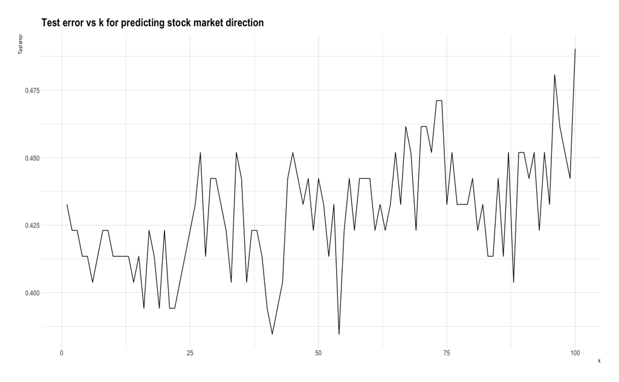

```r
ggplot(knn_errors, aes(x = V1, y = errors)) +
    geom_line() +
    labs(
        title = "Test error vs k for predicting stock market direction",
         x = "k",
        y = "Test error"
        )
```

[output not shown]

```r
which.min(knn_errors$errors)
```

```
[1] 41
```

```r
predicted_knn_41 <- knn(
  train = data.frame(Lag2 = train$Lag2),
  test = data.frame(Lag2 = test$Lag2),
  cl = train$Direction,
  k = 41
)
```

```r
confusionMatrix(
  data = predicted_knn_41,
  reference = test$Direction,
  positive = "Up"
)
```

```
Confusion Matrix and Statistics

          Reference
Prediction Down Up
      Down   22 24
      Up     21 37

               Accuracy : 0.5673
                 95% CI : (0.4665, 0.6641)
    No Information Rate : 0.5865
    P-Value [Acc > NIR] : 0.6921

                  Kappa : 0.117

 Mcnemar's Test P-Value : 0.7656

            Sensitivity : 0.6066
            Specificity : 0.5116
         Pos Pred Value : 0.6379
         Neg Pred Value : 0.4783
             Prevalence : 0.5865
         Detection Rate : 0.3558
   Detection Prevalence : 0.5577
      Balanced Accuracy : 0.5591

       'Positive' Class : Up
```